# 데이터프레임 병합하기

## 필요한 모듈 참조

```python
import pandas as pd
from pandas import DataFrame
```

## #01. 행단위 병합

### 샘플 DataFrame 만들기

```python
df_top = DataFrame({'국어': [90, 82], '수학': [81, 76]}, index=['민철', '철수'])
df_top
```

|  | 국어 | 수학 |
| --- | --- | --- |
| 민철 | 90 | 81 |
| 철수 | 82 | 76 |

```python
df_middle = DataFrame({'국어': [70, 62], '영어': [77, 68]}, index=['영민', '정수'])
df_middle
```

|  | 국어 | 영어 |
| --- | --- | --- |
| 영민 | 70 | 77 |
| 정수 | 62 | 68 |

```python
df_bottom = DataFrame({'영어': [70, 88], '과학': [81, 76]}, index=['민철', '태영'])
df_bottom
```

|  | 영어 | 과학 |
| --- | --- | --- |
| 민철 | 70 | 81 |
| 태영 | 88 | 76 |

## A에 B를 이어 붙이기

- 단순히 세로로 병합만 수행한다.
- 데이터프레임간에 컬럼이 다르더라도 존재하지 않는 컬럼은 빈값(결측치)로 채워 넣는다.

```python
df_a = df_top.append([df_middle, df_bottom], sort=False)
df_a
```

|  | 국어 | 수학 | 영어 | 과학 |
| --- | --- | --- | --- | --- |
| 민철 | 90.0 | 81.0 | NaN | NaN |
| 철수 | 82.0 | 76.0 | NaN | NaN |
| 영민 | 70.0 | NaN | 77.0 | NaN |
| 정수 | 62.0 | NaN | 68.0 | NaN |
| 민철 | NaN | NaN | 70.0 | 81.0 |
| 태영 | NaN | NaN | 88.0 | 76.0 |

### A, B, C를 병합하기

`append()`함수와 동일한 결과

- 단순히 세로로 방향으로 덧붙이는 개념이므로 인덱스가 중복되는 경우도 발생한다.
- sort 파라미터를 생략하거나 True로 지정한 경우 컬럼 순서가 이름순으로 정렬된다.
- (중요) 병합되는 DataFrame간에 컬럼이 서로 다르다면 sort=False 파라미터 필수 지정.

```python
df_b = pd.concat([df_top, df_middle, df_bottom], sort=False)
df_b
```

|  | 국어 | 수학 | 영어 | 과학 |
| --- | --- | --- | --- | --- |
| 민철 | 90.0 | 81.0 | NaN | NaN |
| 철수 | 82.0 | 76.0 | NaN | NaN |
| 영민 | 70.0 | NaN | 77.0 | NaN |
| 정수 | 62.0 | NaN | 68.0 | NaN |
| 민철 | NaN | NaN | 70.0 | 81.0 |
| 태영 | NaN | NaN | 88.0 | 76.0 |

## #02. 열단위 병합

한 번에 두 개의 객체만 병합 가능함

### 인덱스가 지정되지 않은 샘플 데이터 프레임

```python
df_left = DataFrame({'고객번호': [1001, 1002, 1003, 1004], '이름': ['둘리', '도우너', '또치', '길동']})
df_left
```

|  | 고객번호 | 이름 |
| --- | --- | --- |
| 0 | 1001 | 둘리 |
| 1 | 1002 | 도우너 |
| 2 | 1003 | 또치 |
| 3 | 1004 | 길동 |

```python
df_right = DataFrame({'고객번호': [1001, 1002, 1003, 1005], '금액': [10000, 20000, 15000, 5000]})
df_right
```

|  | 고객번호 | 금액 |
| --- | --- | --- |
| 0 | 1001 | 10000 |
| 1 | 1002 | 20000 |
| 2 | 1003 | 15000 |
| 3 | 1005 | 5000 |

### 두 데이터프레임의 공통 컬럼을 기준으로 병합하기

양쪽 데이터프레임에 모두 존재하는 데이터만 보여준다.

> Database의 Inner Join과 같은 개념

```python
# 병합시 제외되는 항목들
# - df_left의 고객번호 1004번 데이터는 df_right의 고객번호 컬럼과 겹치지 않는다.
# - df_right의 고객번호 1005번 데이터는 df_left의 고객번호 컬럼과 겹치지 않는다.
pd.merge(df_left, df_right)
```

|  | 고객번호 | 이름 | 금액 |
| --- | --- | --- | --- |
| 0 | 1001 | 둘리 | 10000 |
| 1 | 1002 | 도우너 | 20000 |
| 2 | 1003 | 또치 | 15000 |

### 왼쪽 데이터프레임을 기준으로 오른쪽 프레임을 병합하기

`how='left'` 파라미터는 왼쪽 DataFrame의 모든 데이터를 보여준다.

> Database의 Left Outer Join과 같은 개념

```python
# df_right의 고객번호 1005은 df_left에 존재하지 않기 때문에 병합되지 않는다.
pd.merge(df_left, df_right, how='left')
```

|  | 고객번호 | 이름 | 금액 |
| --- | --- | --- | --- |
| 0 | 1001 | 둘리 | 10000.0 |
| 1 | 1002 | 도우너 | 20000.0 |
| 2 | 1003 | 또치 | 15000.0 |
| 3 | 1004 | 길동 | NaN |

### 오른쪽 데이터프레임을 기준으로 왼쪽 프레임을 병합하기

how='right' 파라미터는 오른쪽 DataFrame의 모든 데이터를 보여준다.

> Database의 Right Outer Join과 같은 개념

```python
# df_left의 고객번호 1004는 df_right에 존재하지 않기 때문에 병합되지 않는다.
pd.merge(df_left, df_right, how='right')
```

|  | 고객번호 | 이름 | 금액 |
| --- | --- | --- | --- |
| 0 | 1001 | 둘리 | 10000 |
| 1 | 1002 | 도우너 | 20000 |
| 2 | 1003 | 또치 | 15000 |
| 3 | 1005 | NaN | 5000 |

### 양쪽 DataFrame을 모두 병합하기

`how='outer'` 파라미터를 추가하면 공통 컬럼의 값이 한쪽에만 있어도 데이터를 보여준다.

> Database의 Full Outer Join과 같은 개념

```python
pd.merge(df_left, df_right, how='outer')
```

|  | 고객번호 | 이름 | 금액 |
| --- | --- | --- | --- |
| 0 | 1001 | 둘리 | 10000.0 |
| 1 | 1002 | 도우너 | 20000.0 |
| 2 | 1003 | 또치 | 15000.0 |
| 3 | 1004 | 길동 | NaN |
| 4 | 1005 | NaN | 5000.0 |

### 중복되는 데이터가 존재하는 경우의 열단위 병합

모든 경우의 수를 따져서 조합을 만들어 낸다.

```python
df_first = DataFrame({'아이디': ['hello', 'world', 'python', 'hello'], '결재금액': [14000, 13000, 15000, 13000]})
df_first
```

|  | 아이디 | 결재금액 |
| --- | --- | --- |
| 0 | hello | 14000 |
| 1 | world | 13000 |
| 2 | python | 15000 |
| 3 | hello | 13000 |

```python
df_second = DataFrame({'아이디': ['hello', 'python', 'python', 'world'], '적립금': [300, 500, 100, 200]})
df_second
```

|  | 아이디 | 적립금 |
| --- | --- | --- |
| 0 | hello | 300 |
| 1 | python | 500 |
| 2 | python | 100 |
| 3 | world | 200 |

```python
pd.merge(df_first, df_second)
```

|  | 아이디 | 결재금액 | 적립금 |
| --- | --- | --- | --- |
| 0 | hello | 14000 | 300 |
| 1 | hello | 13000 | 300 |
| 2 | world | 13000 | 200 |
| 3 | python | 15000 | 500 |
| 4 | python | 15000 | 100 |

### 공통 컬럼이 두 개 이상 존재하는 경우의 병합

#### 두 데이터프레임에서 이름이 같은 열은 모두 키가 된다.

```python
df_a = DataFrame({'고객명': ['민수', '수영'],
                  '데이터': ['20000', '100000'],
                  '날짜': ['2018-01-01', '2018-01-01']})
df_a
```

|  | 고객명 | 데이터 | 날짜 |
| --- | --- | --- | --- |
| 0 | 민수 | 20000 | 2018-01-01 |
| 1 | 수영 | 100000 | 2018-01-01 |

```python
df_b = DataFrame({'고객명': ['민수', '수영'], '데이터': ['21세', '20세']})
df_b
```

|  | 고객명 | 데이터 |
| --- | --- | --- |
| 0 | 민수 | 21세 |
| 1 | 수영 | 20세 |

```python
# `고객`컬럼과 `데이터`컬럼이 동시에 일치하는 데이터를 찾아 병합한다.
# df_a의 `데이터`는 금액을 의미하지만 df_b의 `데이터`는 나이를 의미하므로 병합되어서는 안된다.
# -> 존재하지 않으므로 결과 없음
pd.merge(df_a, df_b)
```

|  | 고객명 | 데이터 | 날짜 |
| --- | --- | --- | --- |

#### `on` 파라미터를 사용하여 기준 열 지정하기

```python
# 기준 열이 아니면서 이름이 같은 열에는 _x 또는 _y 와 같은 접미사가 붙는다.
merge_tmp = pd.merge(df_a, df_b, on=['고객명'])
merge_tmp
```

|  | 고객명 | 데이터_x | 날짜 | 데이터_y |
| --- | --- | --- | --- | --- |
| 0 | 민수 | 20000 | 2018-01-01 | 21세 |
| 1 | 수영 | 100000 | 2018-01-01 | 20세 |

```python
merge_result = merge_tmp.rename(columns={"데이터_x": "금액", "데이터_y": "나이"})
merge_result
```

|  | 고객명 | 금액 | 날짜 | 나이 |
| --- | --- | --- | --- | --- |
| 0 | 민수 | 20000 | 2018-01-01 | 21세 |
| 1 | 수영 | 100000 | 2018-01-01 | 20세 |

### 공통 컬럼이 존재하지 않는 경우의 병합

left_on, right_on 파라미터를 사용하여 병합의 기준이 되는 열 이름을 명시해야 한다.

```python
국어점수 = DataFrame({'이름': ['영희', '철수'], '국어': [87, 91]})
국어점수
```

|  | 이름 | 국어 |
| --- | --- | --- |
| 0 | 영희 | 87 |
| 1 | 철수 | 91 |

```python
영어점수 = DataFrame({'성명': ['영희', '철수'], '영어': [90, 82]})
영어점수
```

|  | 성명 | 영어 |
| --- | --- | --- |
| 0 | 영희 | 90 |
| 1 | 철수 | 82 |

```python
# 왼쪽의 이름 컬럼과 오른쪽의 성명 컬럼이 같은 데이터를 병합하라는 의미
국어영어 = pd.merge(국어점수, 영어점수, left_on=['이름'], right_on=['성명'])
국어영어
```

|  | 이름 | 국어 | 성명 | 영어 |
| --- | --- | --- | --- | --- |
| 0 | 영희 | 87 | 영희 | 90 |
| 1 | 철수 | 91 | 철수 | 82 |

```python
# 중복되는 값을 갖는 `성명`컬럼은 필요 없으므로 삭제
국어영어.drop('성명', axis=1, inplace=True)
국어영어
```

|  | 이름 | 국어 | 영어 |
| --- | --- | --- | --- |
| 0 | 영희 | 87 | 90 |
| 1 | 철수 | 91 | 82 |

### 인덱스를 기준으로 하는 병합

`left_index=True`, `right_index=True` 파라미터를 선택적으로 사용한다.

```python
수학점수 = DataFrame({'수학': [90, 82]}, index=['민철', '봉구'])
수학점수
```

|  | 수학 |
| --- | --- |
| 민철 | 90 |
| 봉구 | 82 |

```python
과학점수 = DataFrame({'과학': [90, 82]}, index=['민철', '철수'])
과학점수
```

|  | 과학 |
| --- | --- |
| 민철 | 90 |
| 철수 | 82 |

```python
# 왼쪽에서 index를 기준으로 사용하고, 오른쪽에서도 인덱스를 기준으로 사용함
# -> 양쪽 데이터 프레임의 인덱스가 같은 행끼리 병합됨
수학과학 = pd.merge(수학점수, 과학점수, left_index=True, right_index=True)
수학과학
```

|  | 수학 | 과학 |
| --- | --- | --- |
| 민철 | 90 | 90 |

```python
# 인덱스가 겹치지 않더라도 병합하도록 how 파라미터 적용
수학과학 = pd.merge(수학점수, 과학점수, left_index=True, right_index=True, how='outer')
수학과학
```

|  | 수학 | 과학 |
| --- | --- | --- |
| 민철 | 90.0 | 90.0 |
| 봉구 | 82.0 | NaN |
| 철수 | NaN | 82.0 |

### 왼쪽의 인덱스와 오른쪽의 컬럼을 기준으로 병합하기

```python
한국사 = DataFrame({'한국사': [87, 91]}, index=['영희', '철수'])
한국사
```

|  | 한국사 |
| --- | --- |
| 영희 | 87 |
| 철수 | 91 |

```python
세계사 = DataFrame({'세계사': [90, 82], '이름': ['영희', '철수']})
세계사
```

|  | 세계사 | 이름 |
| --- | --- | --- |
| 0 | 90 | 영희 |
| 1 | 82 | 철수 |

```python
역사점수 = pd.merge(한국사, 세계사, left_index=True, right_on=["이름"])
역사점수
```

|  | 한국사 | 세계사 | 이름 |
| --- | --- | --- | --- |
| 0 | 87 | 90 | 영희 |
| 1 | 91 | 82 | 철수 |

```python
# 이름 컬럼을 인덱스로 지정하고 삭제하기
name_list = list(역사점수['이름'])
name_dict = {}

for i, v in enumerate(name_list):
    name_dict[i] = v

역사점수.rename(index=name_dict, inplace=True)
역사점수.drop('이름', axis=1, inplace=True)
역사점수
```

|  | 한국사 | 세계사 |
| --- | --- | --- |
| 영희 | 87 | 90 |
| 철수 | 91 | 82 |

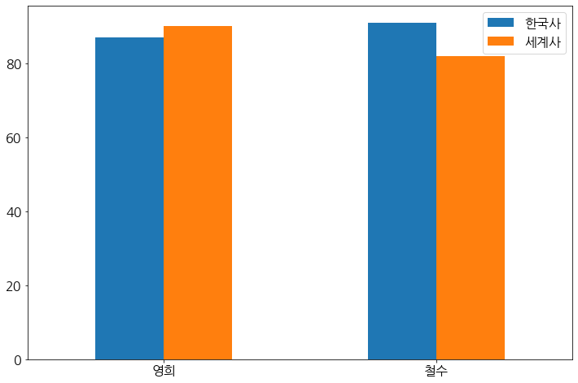

```python
from matplotlib import pyplot
pyplot.rcParams["font.family"] = 'NanumGothic'
pyplot.rcParams["font.size"] = 16
pyplot.rcParams["figure.figsize"] = (12, 8)

역사점수.plot.bar(rot=0)
pyplot.show()
```

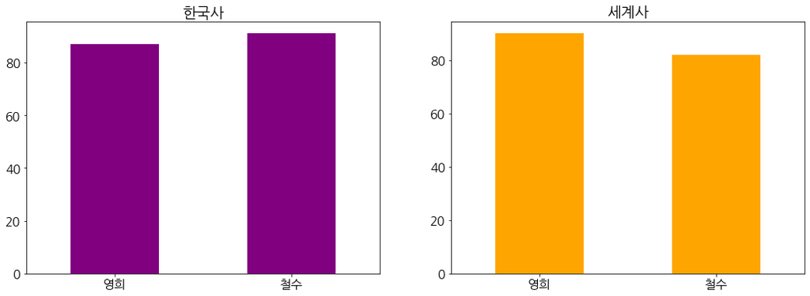

```python
pyplot.rcParams["figure.figsize"] = (18, 6)
pyplot.rcParams["font.size"] = 16

fig = pyplot.figure()

sub1 = fig.add_subplot(1,2,1)
sub1.title.set_text("한국사")
역사점수['한국사'].plot.bar(ax=sub1, rot=0, color='purple')

sub2 = fig.add_subplot(1,2,2)
sub2.title.set_text("세계사")
역사점수['세계사'].plot.bar(ax=sub2, rot=0, color='orange')

pyplot.show()
```